# AVIATION_ACCIDENTS ANALYSIS

#### This analysis centres on aviation accidents within the United States.The ultimate objective is to provide recommendations that ensure safety standards.

```python
import pandas as pd
import numpy as np
import matplotlib.pyplot as plt
import seaborn as sns
```

```python
#I began by loading and reading the file.
df = pd.read_csv('AviationData.csv', encoding = 'cp1252')
df.head()
```

```
c:\Users\Esther Joy Wanjiru\anaconda3\envs\learn-env\lib\site-packages\IPython\core\interactiveshell.py:3145: DtypeWarning: Columns (6,7,28) have mixed types.Specify dtype option on import or set low_memory=False.
  has_raised = await self.run_ast_nodes(code_ast.body, cell_name,
```

|  | Event.Id | Investigation.Type | Accident.Number | Event.Date | Location | Country | Latitude | Longitude | Airport.Code | Airport.Name | ... | Purpose.of.flight | Air.carrier | Total.Fatal.Injuries | Total.Serious.Injuries | Total.Minor.Injuries | Total.Uninjured | Weather.Condition | Broad.phase.of.flight | Report.Status | Publication.Date |
| --- | --- | --- | --- | --- | --- | --- | --- | --- | --- | --- | --- | --- | --- | --- | --- | --- | --- | --- | --- | --- | --- |
| 0 | 20001218X45444 | Accident | SEA87LA080 | 1948-10-24 | MOOSE CREEK, ID | United States | NaN | NaN | NaN | NaN | ... | Personal | NaN | 2 | 0 | 0 | 0 | UNK | Cruise | Probable Cause | NaN |
| 1 | 20001218X45447 | Accident | LAX94LA336 | 1962-07-19 | BRIDGEPORT, CA | United States | NaN | NaN | NaN | NaN | ... | Personal | NaN | 4 | 0 | 0 | 0 | UNK | Unknown | Probable Cause | 19-09-1996 |
| 2 | 20061025X01555 | Accident | NYC07LA005 | 1974-08-30 | Saltville, VA | United States | 37 | -82 | NaN | NaN | ... | Personal | NaN | 3 | nan | nan | nan | IMC | Cruise | Probable Cause | 26-02-2007 |
| 3 | 20001218X45448 | Accident | LAX96LA321 | 1977-06-19 | EUREKA, CA | United States | NaN | NaN | NaN | NaN | ... | Personal | NaN | 2 | 0 | 0 | 0 | IMC | Cruise | Probable Cause | 12-09-2000 |
| 4 | 20041105X01764 | Accident | CHI79FA064 | 1979-08-02 | Canton, OH | United States | NaN | NaN | NaN | NaN | ... | Personal | NaN | 1 | 2 | nan | 0 | VMC | Approach | Probable Cause | 16-04-1980 |

5 rows × 31 columns

```python
assert type(df) == pd.DataFrame
```

```python
df.shape
# There are 88889 entries and 31 columns
```

```
(88889, 31)
```

```python
# Summary statistics of numeric columns
df.describe()
```

|  | Number.of.Engines | Total.Fatal.Injuries | Total.Serious.Injuries | Total.Minor.Injuries | Total.Uninjured |
| --- | --- | --- | --- | --- | --- |
| count | 82805 | 77488 | 76379 | 76956 | 82977 |
| mean | 1 | 1 | 0 | 0 | 5 |
| std | 0 | 5 | 2 | 2 | 28 |
| min | 0 | 0 | 0 | 0 | 0 |
| 25% | 1 | 0 | 0 | 0 | 0 |
| 50% | 1 | 0 | 0 | 0 | 1 |
| 75% | 1 | 0 | 0 | 0 | 2 |
| max | 8 | 349 | 161 | 380 | 699 |

# Data Cleaning

```python
# Let's have a look at our data
df.info()
```

```
<class 'pandas.core.frame.DataFrame'>
RangeIndex: 88889 entries, 0 to 88888
Data columns (total 31 columns):
 #   Column                  Non-Null Count  Dtype
---  ------                  --------------  -----
 0   Event.Id                88889 non-null  object
 1   Investigation.Type      88889 non-null  object
 2   Accident.Number         88889 non-null  object
 3   Event.Date              88889 non-null  object
 4   Location                88837 non-null  object
 5   Country                 88663 non-null  object
 6   Latitude                34382 non-null  object
 7   Longitude               34373 non-null  object
 8   Airport.Code            50249 non-null  object
 9   Airport.Name            52790 non-null  object
```

[output cut: 23 more lines]

```python
# List of data's columns
df.columns
```

```
Index(['Event.Id', 'Investigation.Type', 'Accident.Number', 'Event.Date',
       'Location', 'Country', 'Latitude', 'Longitude', 'Airport.Code',
       'Airport.Name', 'Injury.Severity', 'Aircraft.damage',
       'Aircraft.Category', 'Registration.Number', 'Make', 'Model',
       'Amateur.Built', 'Number.of.Engines', 'Engine.Type', 'FAR.Description',
       'Schedule', 'Purpose.of.flight', 'Air.carrier', 'Total.Fatal.Injuries',
       'Total.Serious.Injuries', 'Total.Minor.Injuries', 'Total.Uninjured',
       'Weather.Condition', 'Broad.phase.of.flight', 'Report.Status',
       'Publication.Date'],
      dtype='object')
```

```python
# highlighted the relevant columns i want to work with.
relevant_columns = [
    "Event.Id",
    "Investigation.Type",
    "Event.Date",
    "Location",
    "Country",
    "Injury.Severity",
    "Aircraft.damage",
    "Make",
    "Model",
    "Number.of.Engines",
    "Purpose.of.flight",
    "Total.Fatal.Injuries",
    "Total.Serious.Injuries",
    "Total.Minor.Injuries",
    "Total.Uninjured",
    "Weather.Condition"
]
```

```python
df = pd.DataFrame(df,columns = relevant_columns)
df.head()
```

|  | Event.Id | Investigation.Type | Event.Date | Location | Country | Injury.Severity | Aircraft.damage | Make | Model | Number.of.Engines | Purpose.of.flight | Total.Fatal.Injuries | Total.Serious.Injuries | Total.Minor.Injuries | Total.Uninjured | Weather.Condition |
| --- | --- | --- | --- | --- | --- | --- | --- | --- | --- | --- | --- | --- | --- | --- | --- | --- |
| 0 | 20001218X45444 | Accident | 1948-10-24 | MOOSE CREEK, ID | United States | Fatal(2) | Destroyed | Stinson | 108-3 | 1 | Personal | 2 | 0 | 0 | 0 | UNK |
| 1 | 20001218X45447 | Accident | 1962-07-19 | BRIDGEPORT, CA | United States | Fatal(4) | Destroyed | Piper | PA24-180 | 1 | Personal | 4 | 0 | 0 | 0 | UNK |
| 2 | 20061025X01555 | Accident | 1974-08-30 | Saltville, VA | United States | Fatal(3) | Destroyed | Cessna | 172M | 1 | Personal | 3 | nan | nan | nan | IMC |
| 3 | 20001218X45448 | Accident | 1977-06-19 | EUREKA, CA | United States | Fatal(2) | Destroyed | Rockwell | 112 | 1 | Personal | 2 | 0 | 0 | 0 | IMC |
| 4 | 20041105X01764 | Accident | 1979-08-02 | Canton, OH | United States | Fatal(1) | Destroyed | Cessna | 501 | nan | Personal | 1 | 2 | nan | 0 | VMC |

```python
#Began by extracting data from the 'injury severity and total fatal injuries columns, I create a new Fatality column with less missing numerical data than 'Total.Fatal.Injuries'

df['Fatality'] = df['Injury.Severity'].str.extract(r'\((\d+)\)')
df['Fatality'].replace({'Non-Fatal': 0, 'Minor': 0, 'Serious':0, 'Incident':0},inplace=True)
df['Fatality'].fillna(df['Injury.Severity'] , inplace=True)
df.replace('Unavailable',np.nan, inplace=True)
df['Fatality'] = pd.to_numeric(df['Fatality'], errors = 'coerce').fillna(0).astype(int)
df['Fatality'] = df.apply(lambda row: row['Total.Fatal.Injuries'] if 'Fatal' in str(row['Injury.Severity'])else row ['Fatality'],axis=1)
pd.options.display.float_format = '{:.0f}'.format
df.head()
```

|  | Event.Id | Investigation.Type | Event.Date | Location | Country | Injury.Severity | Aircraft.damage | Make | Model | Number.of.Engines | Purpose.of.flight | Total.Fatal.Injuries | Total.Serious.Injuries | Total.Minor.Injuries | Total.Uninjured | Weather.Condition | Fatality |
| --- | --- | --- | --- | --- | --- | --- | --- | --- | --- | --- | --- | --- | --- | --- | --- | --- | --- |
| 0 | 20001218X45444 | Accident | 1948-10-24 | MOOSE CREEK, ID | United States | Fatal(2) | Destroyed | Stinson | 108-3 | 1 | Personal | 2 | 0 | 0 | 0 | UNK | 2 |
| 1 | 20001218X45447 | Accident | 1962-07-19 | BRIDGEPORT, CA | United States | Fatal(4) | Destroyed | Piper | PA24-180 | 1 | Personal | 4 | 0 | 0 | 0 | UNK | 4 |
| 2 | 20061025X01555 | Accident | 1974-08-30 | Saltville, VA | United States | Fatal(3) | Destroyed | Cessna | 172M | 1 | Personal | 3 | nan | nan | nan | IMC | 3 |
| 3 | 20001218X45448 | Accident | 1977-06-19 | EUREKA, CA | United States | Fatal(2) | Destroyed | Rockwell | 112 | 1 | Personal | 2 | 0 | 0 | 0 | IMC | 2 |
| 4 | 20041105X01764 | Accident | 1979-08-02 | Canton, OH | United States | Fatal(1) | Destroyed | Cessna | 501 | nan | Personal | 1 | 2 | nan | 0 | VMC | 1 |

```python
#I noticed Fatality column has  object type so I change it to numeric
df['Fatality'] = pd.to_numeric(df['Fatality'], errors = 'coerce').astype(object)
df.head()
```

|  | Event.Id | Investigation.Type | Event.Date | Location | Country | Injury.Severity | Aircraft.damage | Make | Model | Number.of.Engines | Purpose.of.flight | Total.Fatal.Injuries | Total.Serious.Injuries | Total.Minor.Injuries | Total.Uninjured | Weather.Condition | Fatality |
| --- | --- | --- | --- | --- | --- | --- | --- | --- | --- | --- | --- | --- | --- | --- | --- | --- | --- |
| 0 | 20001218X45444 | Accident | 1948-10-24 | MOOSE CREEK, ID | United States | Fatal(2) | Destroyed | Stinson | 108-3 | 1 | Personal | 2 | 0 | 0 | 0 | UNK | 2 |
| 1 | 20001218X45447 | Accident | 1962-07-19 | BRIDGEPORT, CA | United States | Fatal(4) | Destroyed | Piper | PA24-180 | 1 | Personal | 4 | 0 | 0 | 0 | UNK | 4 |
| 2 | 20061025X01555 | Accident | 1974-08-30 | Saltville, VA | United States | Fatal(3) | Destroyed | Cessna | 172M | 1 | Personal | 3 | nan | nan | nan | IMC | 3 |
| 3 | 20001218X45448 | Accident | 1977-06-19 | EUREKA, CA | United States | Fatal(2) | Destroyed | Rockwell | 112 | 1 | Personal | 2 | 0 | 0 | 0 | IMC | 2 |
| 4 | 20041105X01764 | Accident | 1979-08-02 | Canton, OH | United States | Fatal(1) | Destroyed | Cessna | 501 | nan | Personal | 1 | 2 | nan | 0 | VMC | 1 |

```python
# My Fatality column with more accurate representation of Fatality counts has been created
df['Fatality'].value_counts()
```

```
0      60423
1       8867
2       5172
3       1588
4       1103
       ...
58         1
60         1
123        1
64         1
78         1
Name: Fatality, Length: 125, dtype: int64
```

```python
# I have dropped the Total Fatal_injuries column
df.drop(columns = ['Total.Fatal.Injuries'], inplace= True)
```

```python
#confirm the Fatality column has a object data type
assert df['Fatality'].dtype == object
```

```python
#I focused on the US data since it is overrepresented.So i first checked the count of the different countries.
df['Country'].value_counts()
```

```
United States     82248
Brazil              374
Canada              359
Mexico              358
United Kingdom      344
                  ...
Gibraltar             1
Wolseley              1
Nauru                 1
Cambodia              1
Liberia               1
Name: Country, Length: 219, dtype: int64
```

```python
#created a new dataframe to focus on the United States
df_ust = df[df['Country'] == 'United States']
df_br = df[df['Country'] == 'Brazil']
df_ust, df_br.reset_index(drop=True, inplace= True)
df.head()
```

|  | Event.Id | Investigation.Type | Event.Date | Location | Country | Injury.Severity | Aircraft.damage | Make | Model | Number.of.Engines | Purpose.of.flight | Total.Serious.Injuries | Total.Minor.Injuries | Total.Uninjured | Weather.Condition | Fatality |
| --- | --- | --- | --- | --- | --- | --- | --- | --- | --- | --- | --- | --- | --- | --- | --- | --- |
| 0 | 20001218X45444 | Accident | 1948-10-24 | MOOSE CREEK, ID | United States | Fatal(2) | Destroyed | Stinson | 108-3 | 1 | Personal | 0 | 0 | 0 | UNK | 2 |
| 1 | 20001218X45447 | Accident | 1962-07-19 | BRIDGEPORT, CA | United States | Fatal(4) | Destroyed | Piper | PA24-180 | 1 | Personal | 0 | 0 | 0 | UNK | 4 |
| 2 | 20061025X01555 | Accident | 1974-08-30 | Saltville, VA | United States | Fatal(3) | Destroyed | Cessna | 172M | 1 | Personal | nan | nan | nan | IMC | 3 |
| 3 | 20001218X45448 | Accident | 1977-06-19 | EUREKA, CA | United States | Fatal(2) | Destroyed | Rockwell | 112 | 1 | Personal | 0 | 0 | 0 | IMC | 2 |
| 4 | 20041105X01764 | Accident | 1979-08-02 | Canton, OH | United States | Fatal(1) | Destroyed | Cessna | 501 | nan | Personal | 2 | nan | 0 | VMC | 1 |

```python
df_State_Codes = 'State_Code'
df_State_Codes = pd.read_csv('USState_Codes.csv')
```

```python
#created a list of US state codes.

State_Code = [
    'AL','AK','AZ','AR','CA','CO','CT','DE','FL','GA',
    'HI','ID','IL','IN','IA','KS','KY','LA','ME','MD',
    'MA','MI','MN','MS','MO','MT','NE','NE','NH','NJ',
    'NM','NY','NC','ND','OH','OK','OR','PA','RI','SC',
    'SD','TN','TX','UT','VT','VA','WA','WV','WI','WY'
]
df_ust['Event.Date'] = pd.to_datetime(df_ust['Event.Date'], format='%Y-%m-%d')
df_ust['Month'] = df_ust['Event.Date'].dt.month
df_ust['Year'] = df_ust['Event.Date'].dt.year
def extract_City_State_Code(Location):
    if pd.notna(Location):
       Location = Location.strip()
       last_two_chars = Location[-2:].upper()
       if last_two_chars in State_Code:
        return Location[:-3].strip(),last_two_chars

    else:
        return Location, 'Not Applicable'

df_ust[['City','State']] = df_ust['Location' ].apply( extract_City_State_Code).apply(pd.Series)
df.head()
```

|  | Event.Id | Investigation.Type | Event.Date | Location | Country | Injury.Severity | Aircraft.damage | Make | Model | Number.of.Engines | Purpose.of.flight | Total.Serious.Injuries | Total.Minor.Injuries | Total.Uninjured | Weather.Condition | Fatality |
| --- | --- | --- | --- | --- | --- | --- | --- | --- | --- | --- | --- | --- | --- | --- | --- | --- |
| 0 | 20001218X45444 | Accident | 1948-10-24 | MOOSE CREEK, ID | United States | Fatal(2) | Destroyed | Stinson | 108-3 | 1 | Personal | 0 | 0 | 0 | UNK | 2 |
| 1 | 20001218X45447 | Accident | 1962-07-19 | BRIDGEPORT, CA | United States | Fatal(4) | Destroyed | Piper | PA24-180 | 1 | Personal | 0 | 0 | 0 | UNK | 4 |
| 2 | 20061025X01555 | Accident | 1974-08-30 | Saltville, VA | United States | Fatal(3) | Destroyed | Cessna | 172M | 1 | Personal | nan | nan | nan | IMC | 3 |
| 3 | 20001218X45448 | Accident | 1977-06-19 | EUREKA, CA | United States | Fatal(2) | Destroyed | Rockwell | 112 | 1 | Personal | 0 | 0 | 0 | IMC | 2 |
| 4 | 20041105X01764 | Accident | 1979-08-02 | Canton, OH | United States | Fatal(1) | Destroyed | Cessna | 501 | nan | Personal | 2 | nan | 0 | VMC | 1 |

```python
#changed date type to appropriate format and created a month and year column respectively out of date
df['Event.Date'] = pd.to_datetime(df['Event.Date'], format='%Y-%m-%d')
df['Month'] = df['Event.Date'].dt.month
df.head()
```

|  | Event.Id | Investigation.Type | Event.Date | Location | Country | Injury.Severity | Aircraft.damage | Make | Model | Number.of.Engines | Purpose.of.flight | Total.Serious.Injuries | Total.Minor.Injuries | Total.Uninjured | Weather.Condition | Fatality | Month |
| --- | --- | --- | --- | --- | --- | --- | --- | --- | --- | --- | --- | --- | --- | --- | --- | --- | --- |
| 0 | 20001218X45444 | Accident | 1948-10-24 | MOOSE CREEK, ID | United States | Fatal(2) | Destroyed | Stinson | 108-3 | 1 | Personal | 0 | 0 | 0 | UNK | 2 | 10 |
| 1 | 20001218X45447 | Accident | 1962-07-19 | BRIDGEPORT, CA | United States | Fatal(4) | Destroyed | Piper | PA24-180 | 1 | Personal | 0 | 0 | 0 | UNK | 4 | 7 |
| 2 | 20061025X01555 | Accident | 1974-08-30 | Saltville, VA | United States | Fatal(3) | Destroyed | Cessna | 172M | 1 | Personal | nan | nan | nan | IMC | 3 | 8 |
| 3 | 20001218X45448 | Accident | 1977-06-19 | EUREKA, CA | United States | Fatal(2) | Destroyed | Rockwell | 112 | 1 | Personal | 0 | 0 | 0 | IMC | 2 | 6 |
| 4 | 20041105X01764 | Accident | 1979-08-02 | Canton, OH | United States | Fatal(1) | Destroyed | Cessna | 501 | nan | Personal | 2 | nan | 0 | VMC | 1 | 8 |

```python
df['Year'] = df['Event.Date'].dt.year
df.head()
```

|  | Event.Id | Investigation.Type | Event.Date | Location | Country | Injury.Severity | Aircraft.damage | Make | Model | Number.of.Engines | Purpose.of.flight | Total.Serious.Injuries | Total.Minor.Injuries | Total.Uninjured | Weather.Condition | Fatality | Month | Year |
| --- | --- | --- | --- | --- | --- | --- | --- | --- | --- | --- | --- | --- | --- | --- | --- | --- | --- | --- |
| 0 | 20001218X45444 | Accident | 1948-10-24 | MOOSE CREEK, ID | United States | Fatal(2) | Destroyed | Stinson | 108-3 | 1 | Personal | 0 | 0 | 0 | UNK | 2 | 10 | 1948 |
| 1 | 20001218X45447 | Accident | 1962-07-19 | BRIDGEPORT, CA | United States | Fatal(4) | Destroyed | Piper | PA24-180 | 1 | Personal | 0 | 0 | 0 | UNK | 4 | 7 | 1962 |
| 2 | 20061025X01555 | Accident | 1974-08-30 | Saltville, VA | United States | Fatal(3) | Destroyed | Cessna | 172M | 1 | Personal | nan | nan | nan | IMC | 3 | 8 | 1974 |
| 3 | 20001218X45448 | Accident | 1977-06-19 | EUREKA, CA | United States | Fatal(2) | Destroyed | Rockwell | 112 | 1 | Personal | 0 | 0 | 0 | IMC | 2 | 6 | 1977 |
| 4 | 20041105X01764 | Accident | 1979-08-02 | Canton, OH | United States | Fatal(1) | Destroyed | Cessna | 501 | nan | Personal | 2 | nan | 0 | VMC | 1 | 8 | 1979 |

# Visualization and Exploratory Data Analysis

```
<function matplotlib.pyplot.show(close=None, block=None)>
```

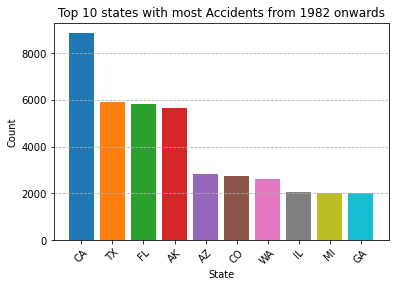

```python
#Below is a bar graph showing the rate of accidents for top 10 states from 1982 onwards.
years = df_ust[df_ust['Year']>= 1982]
Top_10_states = years['State'].value_counts().head(10)
colors = plt.cm.tab10(range(len(Top_10_states)))

plt.figure(figsize=(6,4))
bars = plt.bar(Top_10_states.index, Top_10_states.values, color= colors)
plt.xlabel('State')
plt.ylabel('Count')
plt.title('Top 10 states with most Accidents from 1982 onwards')
plt.xticks(rotation=45)
plt.grid(axis='y', linestyle= '--')

plt.show
```

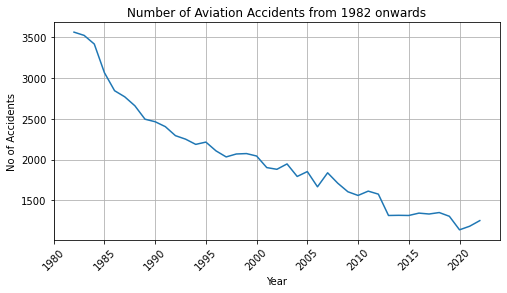

```python
#This is a line plot of US aviation accidents from 1982 onwards.

df['Year'] = df['Event.Date'].dt.year
df_ust = df_ust[df_ust['Year']>= 1982]
accidents_by_year = df_ust['Year'].value_counts().sort_index()

plt.figure(figsize=(8,4))
plt.plot(accidents_by_year.index, accidents_by_year.values, linestyle='-')
plt.title('Number of Aviation Accidents from 1982 onwards')
plt.xlabel('Year')
plt.ylabel('No of Accidents')
plt.grid(True)
plt.xticks(rotation=45)
plt.show()

#There has been a decrease in the number of accidents as years go by.Which suggest improvements
# in aviation safety, regulatory measures, technology, training, and overall risk management within the aviation industry.
```

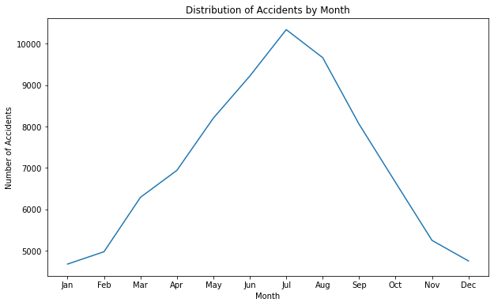

```python
# A distribution of accidents by months.

df['Month'] = df['Event.Date'].dt.month
Accidents = df[df['Investigation.Type'] == 'Accident']

Month = ['Jan', 'Feb', 'Mar', 'Apr', 'May', 'Jun', 'Jul', 'Aug', 'Sep', 'Oct', 'Nov', 'Dec']

Number_of_Accidents = Accidents.groupby('Month')['Investigation.Type'].count()

Number_of_Accidents = Number_of_Accidents.reindex(range(1, 13), fill_value=0)

fig = plt.figure(figsize=(10, 6))
axes = plt.subplot(1, 1, 1)

axes.set_title('Distribution of Accidents by Month')
axes.set_xlabel('Month')
axes.set_ylabel('Number of Accidents')

axes.set_xticks(range(12))
axes.set_xticklabels(Month)

axes.plot(range(12), Number_of_Accidents)

plt.show()
```

```python
#Exploring the rate of fatalities to see what year had the most percentage of deadly accidents
# 2001 has the most percentage of Fatalities. Not sure if high ratio is because of the victims of 9/11 terror attack


df['Year'] = df['Event.Date'].dt.year
df_ust= df[df['Year']>= 1982]
Yearly_stats = df_ust.groupby('Year')['Fatality'].agg(['count','sum'])
Yearly_stats['Fatality_Percentage'] = (Yearly_stats['sum']/Yearly_stats['count']) * 10
Yearly_stats['Fatality_Percentage'].fillna(-np.inf, inplace=True)

Year_with_the_highest_percentage = Yearly_stats['Fatality_Percentage'].idxmax()
highest_percentage = Yearly_stats['Fatality_Percentage'].max()

print(f'Year with the highest percentage of fatalities(1982 onwards):{Year_with_the_highest_percentage}')
print(f'highest percentage of fatalities:{highest_percentage:.2f}%')
```

```
Year with the highest percentage of fatalities(1982 onwards):2001
highest percentage of fatalities:34.03%
```

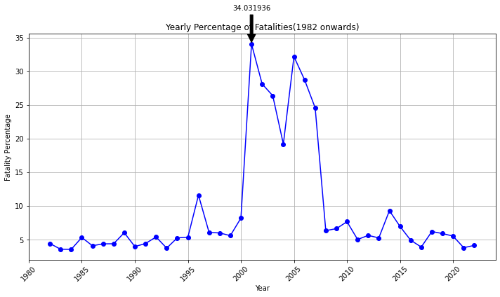

```python
#Below is a visualization of the percentage fatalities.
fig, ax = plt.subplots(figsize=(10, 6))
ax.plot(Yearly_stats.index, Yearly_stats['Fatality_Percentage'], marker='o', color='b', linestyle='-')
plt.annotate(f'{highest_percentage:2f}',
            xy=(Year_with_the_highest_percentage,highest_percentage),
            xytext=(Year_with_the_highest_percentage,highest_percentage+5),
            arrowprops=dict(facecolor='black', shrink=0.05),
            ha='center')

plt.title('Yearly Percentage of Fatalities(1982 onwards)')
plt.xlabel('Year')
plt.ylabel('Fatality Percentage')

plt.grid(True)
plt.xticks(rotation=45)
plt.tight_layout()
```

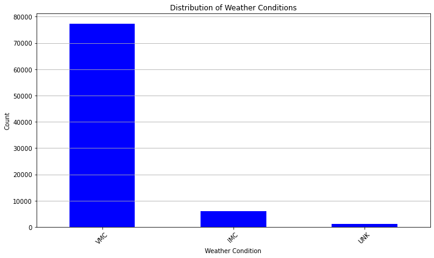

```python
#explore if there is a meaningful relationship between weather condition and accidents

df_ust['Weather.Condition'] = df_ust['Weather.Condition'].str.upper()
weather_counts= df_ust['Weather.Condition'].value_counts()

plt.figure(figsize=(10,6))
weather_counts.plot(kind= 'bar', color = 'blue')

plt.title('Distribution of Weather Conditions')
plt.xlabel('Weather Condition')
plt.ylabel('Count')

plt.xticks(rotation= 45)
plt.grid(axis = 'y')
plt.tight_layout()
plt.show()
```

```python
# Trying to see the relationship between Makes, Models and engine types with accidents

make_model_counts = df_ust.groupby(['Make', 'Model']).size().reset_index(name= 'AccidentCount')
sorted_make_model_counts = make_model_counts.sort_values(by= 'AccidentCount', ascending= False)
sorted_make_model_counts
```

|  | Make | Model | AccidentCount |
| --- | --- | --- | --- |
| 5745 | Cessna | 152 | 2168 |
| 5767 | Cessna | 172 | 1254 |
| 5811 | Cessna | 172N | 996 |
| 15078 | Piper | PA-28-140 | 812 |
| 5720 | Cessna | 150 | 716 |
| ... | ... | ... | ... |
| 8312 | Engineering & Research | ERCOUPE 415-CD | 1 |
| 8314 | Engineering and Research | 415C | 1 |
| 8315 | Engleman | PITTS S1 | 1 |
| 8316 | English | PIETENPOL AIRCAMPER | 1 |
| 20134 | unknown | kit | 1 |

20135 rows × 3 columns

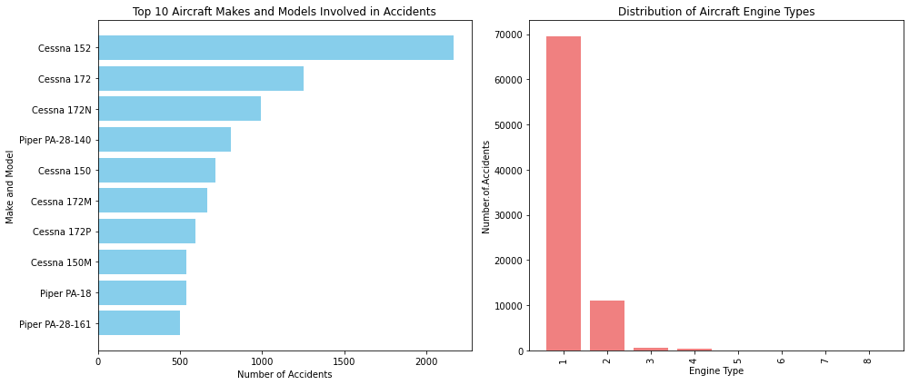

```python
df_ust['Number.of.Engines'] = df_ust['Number.of.Engines'].replace(0.0, np.nan)

# Group by 'Make' and 'Model' and count occurrences
make_model_accident_counts = df_ust.groupby(['Make', 'Model']).size().reset_index(name='AccidentCount')
make_model_accident_counts = make_model_accident_counts.sort_values(by='AccidentCount', ascending=False)

# Plotting
fig, axes = plt.subplots(1, 2, figsize=(14, 6))

# Top 10 Makes and Models by Accident Count
top_10_make_model = make_model_accident_counts.head(10)
axes[0].barh(top_10_make_model['Make'] + ' ' + top_10_make_model['Model'], top_10_make_model['AccidentCount'], color='skyblue')
axes[0].set_xlabel('Number of Accidents')
axes[0].set_ylabel('Make and Model')
axes[0].set_title('Top 10 Aircraft Makes and Models Involved in Accidents')
axes[0].invert_yaxis()

# Engine Types Distribution
engines_counts = df_ust['Number.of.Engines'].dropna().value_counts()
axes[1].bar(engines_counts.index, engines_counts.values, color='lightcoral')
axes[1].set_title('Distribution of Aircraft Engine Types')
axes[1].set_xlabel('Engine Type')
axes[1].set_ylabel('Number.of.Accidents')
axes[1].tick_params(axis='x', rotation=90)

plt.tight_layout()
plt.show()
```

# Conclusions.

From the observations, it can be concluded that favorable weather conditions do not necessarily prevent accidents in aviation. This suggests that other factors, such as pilot error, mechanical failure, or operational issues, play a significant role in aviation accidents.

Although there has been a reduction in the overall number of aviation accidents, California, Texas, and Florida are states where accidents occur more frequently.

Additionally, the fact that specific aircraft makes, models, and engine types are involved in accidents more frequently suggests potential design or operational vulnerabilities with these aircraft. This could highlight the need for more stringent maintenance, inspections, or operational protocols for those particular types of aircraft.

# RECOMMENDATIONS

1. Increasing oversight and inspections of flight operations, especially for general aviation and smaller airfields.
2. Implementing additional training programs for pilots, particularly in handling high-traffic or complex airspace conditions.
3. Collaborating with aircraft manufacturers to address potential design flaws or maintenance challenges.
4. Issuing safety advisories or requiring additional checks for specific aircraft types, especially those that have shown higher accident rates.
5. Enhancing the existing safety protocols and maintenance routines for high-risk aircraft types.
6. Providing additional pilot training on recognizing and mitigating risks related to mechanical issues, flight path errors, or situational awareness in routine operations.
7. Conducting recurrent training programs that emphasize the importance of operational discipline, even during routine or seemingly "safe" flying conditions.
8. Promoting the use of modern flight safety technologies, such as enhanced ground proximity warnings.
9. Review and update regulations for aircraft operations, particularly in high-traffic areas, to ensure they are aligned with the latest safety standards and best practices.